# STSCI 4630 - Lec 19

Harry Lu

April 11, 2019

**Black-Scholes**

$$\left\{\begin{align}
\textbf{C}&=\Phi(d_1)S_0-\Phi(d_2)Ke^{-rT}\\\
d_1&=\frac{\ln\left(\frac{S_0}{K}\right)+\left(r+\frac{\sigma^2}{2}\right)T}{\sigma\sqrt{T}}\\
d_2&=d_1-\sigma\sqrt{T}
\end{align}\right.$$

- $S_0$: stock price
- $K$: strike price
- $r$: per-period risk-free rate
- $T$: expiry time
- $\sigma$: volatility
- $\mu$: drift
- $\Phi$: standard normal cdf

Note: $\textbf{C}$ depends on $S_0$, $K$, $\sigma$, $r$, $T$.

$\textbf{C}$ prices American and European call options. To price European put option,

$$\textbf{P}=\textbf{C}+e^{-rT}K-S_0$$

The implied volatility is the value of $\sigma$ that makes the Black-Scholes price the same as the actual price.

Volatility Smile: Plot the implied volatility $V$ as a function of the strike price $K$. It usually produces a bowl-shaped function.

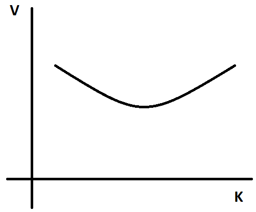

Volatility Surface: plot $V$ as a function of $K$ and expiry date $T$. Idea: see how the volatility smile changes with the expiry date.

How do option prices change over time? Given interval $[0,T]$, $0\leq t\leq T$

Let $\textbf{C}_t$ be the price of the option at time $t$. $\textbf{C}_t$ is the price of an option with strike price $K$, stock price $S_0$, and expiry $T-t$.

$$\left\{\begin{align}
\textbf{C}_t&=\Phi(d_1)S_t-\Phi(d_2)Ke^{-r(T-t)}\\\
d_1&=\frac{\ln\left(\frac{S_t}{K}\right)+\left(r+\frac{\sigma^2}{2}\right)(T-t)}{\sigma\sqrt{T-t}}\\
d_2&=d_1-\sigma\sqrt{T-t}
\end{align}\right.$$

European put:

$$\textbf{P}_t=\textbf{C}_t+e^{-r(T-t)}K-S_t$$

**The Greeks**

$$\textbf{C}_t=C(S_t,K,\sigma,r,T-t)\rightarrow\text{imagine }K,T$$

**Delta**

$$\Delta=\frac{\partial\textbf{C}_t}{\partial S_t}$$

$$\delta\textbf{C}_t=\Delta\cdot\delta S_t\rightarrow\delta S_t=\frac{1}{\Delta}\cdot\delta\textbf{C}_t$$

Idea: the change in the price of the one share of stock can be replicated by the change in the price of $\frac{1}{\Delta}$ options.

Return for one share of stock is replicated by the return on $\frac{1}{\Delta}$ options.

$$\delta S_t=\frac{1}{\Delta}\cdot\delta\textbf{C}_t\Rightarrow\frac{\delta S_t}{S_t}=\frac{1}{\Delta}\cdot\frac{\delta\textbf{C}_t}{S_t}\Rightarrow\frac{\delta S_t}{S_t}=\frac{1}{\Delta}\cdot\frac{\textbf{C}_t}{S_t}\cdot\frac{\delta\textbf{C}_t}{\textbf{C}_t}$$

So $\frac{\delta\textbf{C}_t}{\textbf{C}_t}=\frac{\Delta\cdot S_t}{\textbf{C}_t}\cdot\frac{\delta S_t}{S_t}$, where $\frac{\Delta\cdot S_t}{\textbf{C}_t}$ is called the leverage.

Idea:

$$\text{net return for the option}=\text{leverage}\times\text{net return for the stock}$$

Suppose we want to replicate the change in price of $\$M$ worth of stock.

$\$M$ of stock has $\frac{M}{S_t}$ shares, the change in price of these shares is replicated by $\frac{1}{\Delta}\cdot\frac{M}{S_t}$ options. The price of those options is $\textbf{C}_t\cdot\frac{1}{\Delta}\cdot\frac{M}{S_t}=\text{leverage}^{-1}\cdot M$

Let $\textbf{P}_t=\textbf{C}_t+e^{-r(T-t)}K-S_t$ be the price of a European put

$$\frac{\partial\textbf{P}_t}{\partial S_t}=\Delta-1\quad\text{where }\Delta=\frac{\partial\textbf{C}_t}{\partial S_t},-\delta\textbf{P}_t=(1-\Delta)\cdot\delta S_t$$

So the change in price of one share of stock is hedged by the change in price of $\frac{1}{\Delta-1}$ put options. Typically, $\frac{\textbf{P}_t}{\Delta-1}$ is much less than $S_t$.

The change in $\$M$ of stock is hedged by the change in $\frac{1}{\Delta-1}\cdot\frac{M}{S_t}$ put options. The price of these options is

$$\frac{\textbf{P}_t}{\Delta-1}\cdot\frac{M}{S_t}=\left[\frac{(\Delta-1)S_t}{\textbf{P}_t}\right]^{-1}\cdot M=\text{put leverage}^{-1}\cdot M$$

Note: $\Delta=\Phi(d_1)$

**Theta**

$$\Theta=\frac{\partial\textbf{C}_t}{\partial t}$$

**Rho**

$$P=\frac{\partial\textbf{C}_t}{\partial r}$$

**Vega**

$$V=\frac{\partial\textbf{C}_t}{\partial\sigma}$$

**Chapter 9. Fixed Income Securities**

Zero coupon bonds - discount bonds

Have a “par” value paid to the holder at maturity.

Suppose a discount bond pays $\$100$ in $30$ years, and the annual interest rate is $3\%$.

- Under annual compounding, current value is $\frac{100}{(1+0.03)^{30}}\approx41.20$
- Compounded weekly, $\text{CV}=\frac{100}{\left(1+\frac{0.03}{52}\right)^{52\times30}}\approx40.67$
- Compounded continuously, $\text{CV}=\frac{100}{e^{0.03\times30}}\approx40.66$

Thanks to *Zhenjie Shen* for help with the notes.